# Biostat 200C Homework 5

Due June 2 @ 11:59PM

Cyrene Arputhasamy

## Q1. Balanced one-way ANOVA random effects model

Consider the balanced one-way ANOVA random effects model with $a$ levels and $n$ observations in each level
$$y_{ij} = \mu + \alpha_i + \epsilon_{ij}, \quad i=1,\ldots,a, \quad
j=1,\ldots,n.$$
where $\alpha_i$ are iid from $N(0,\sigma_\alpha^2)$, $\epsilon_{ij}$ are iid from $N(0, \sigma_\epsilon^2)$.

1. Derive the ANOVA estimate for $\mu$, $\sigma_\alpha^2$, and $\sigma_{\epsilon}^2$. Specifically show that
   $$\begin{eqnarray*}
   \mathbb{E}(\bar y_{\cdot \cdot}) &=& \mathbb{E} \left(
   \frac{\sum_{ij} y_{ij}}{na} \right) = \mu \\
   \mathbb{E} (\text{SSE}) &=& \mathbb{E} \left[ \sum_{i=1}^a
   \sum_{j=1}^n (y_{ij} - \bar{y}_{i \cdot})^2 \right] = a(n-1)
   \sigma_{\epsilon}^2 \\
   \mathbb{E} (\text{SSA}) &=& \mathbb{E} \left[ \sum_{i=1}^a
   \sum_{j=1}^n (\bar{y}_{i \cdot} - \bar{y}_{\cdot \cdot})^2 \right] =
   (a-1)(n \sigma_{\alpha}^2 + \sigma_{\epsilon}^2),
   \end{eqnarray*}$$
   which can be solved to obtain ANOVA estimate
   $$\begin{eqnarray*}
   \widehat{\mu} &=& \frac{\sum_{ij} y_{ij}}{na}, \\
   \widehat{\sigma}_{\epsilon}^2 &=& \frac{\text{SSE}}{a(n-1)}, \\
   \widehat{\sigma}_{\alpha}^2 &=& \frac{\text{SSA}/(a-1) -
   \widehat{\sigma}_{\epsilon}^2}{n}.
   \end{eqnarray*}$$

**Solution:**

- $\mathbb{E}(\bar y_{\cdot \cdot})$

$$\begin{eqnarray*}
\mathbb{E}(y_{ij}) &=& \mathbb{E}(\mu + \alpha_i +
\epsilon_{ij}) \\
&=& \mathbb{E}\mu + \mathbb{E}\alpha_i + \mathbb{E}\epsilon_{ij}
\\
&=& \mu + 0 + 0 = \mu \\
\\
\mathbb{E}\frac{\sum_{ij}y_{ij}}{na} &=& \frac{\sum_{ij}
\mathbb{E}(y_{ij})}{na} \\
&=& \frac{\sum_{ij}\mu}{na} = \mu
\end{eqnarray*}$$

- SSE

$$\begin{eqnarray*}
\mathbb{E} \left[ \sum_{i=1}^a \sum_{j=1}^n (y_{ij} - \bar{y}_{i
\cdot})^2 \right] &=& \sum_{i=1}^a \mathbb{E}\left[ \sum_{j=1}^n
(y_{ij} - \bar{y}_{i \cdot})^2 \right] \\
y_{ij} &=& \mu + \alpha_i+\epsilon_{ij} \\
\bar{y}_{i \cdot} &=& \frac{1}{n} \sum_{j=1}^n(\mu + \alpha_i +
\epsilon_{ij}) = \mu + \alpha_i + \bar{\epsilon}_{i \cdot} \\
y_{ij} - \bar{y}_{i \cdot} &=& \epsilon_{ij} - \bar{\epsilon}_{i
\cdot} \\
\mathbb{E}(\sum(\epsilon_{ij} - \bar{\epsilon}_{i \cdot})^2) &=&
(n-1)\sigma_\epsilon^2 \\
\sum_{i=1}^a\mathbb{E}\left[\sum_{j=1}^n(\epsilon_{ij} -
\bar{\epsilon}_{i \cdot})^2 \right] &=& \sum^a
(n-1)\sigma_\epsilon^2 \\
&=& a(n-1)\sigma_\epsilon^2
\end{eqnarray*}$$

- SSA

$$\begin{eqnarray*}
\mathbb{E}(\text(SST)) &=& \mathbb{E}\left[ \sum^a \sum^n
(y_{ij} - \bar{y}_{\cdot \cdot})^2 \right] \\
\mathbb{E}(SST) &=& \mathbb{E}\left[\sum^a \sum^n (\mu +
\alpha_i + \epsilon_{ij} - (\mu + \bar{\alpha} + \bar{\epsilon_{\cdot
\cdot}}))^2\right] \\
&=& \mathbb{E}\left[\sum^a \sum^n ((\alpha_i - \bar{\alpha}) +
(\epsilon_{ij} - \bar{\epsilon_{\cdot \cdot}}))^2\right] \\
&=& \mathbb{E}\left[\sum^a \sum^n (\alpha_i - \bar{\alpha})^2
\right] + \mathbb{E}\left[\sum^a \sum^n (\epsilon_{ij} -
\bar{\epsilon_{\cdot \cdot}})^2 \right] \\
&=& n\mathbb{E}\left[\sum^a(\alpha_i - \bar{\alpha})^2\right] +
\mathbb{E}\left[\sum^a \sum^n (\epsilon_{ij} - \bar{\epsilon_{\cdot
\cdot}})^2 \right] \\
&=& n(a-1) \sigma_{\alpha}^2 + (na-1)\sigma_{\epsilon}^2 \\
\\
\Rightarrow \mathbb{E}(SSA) &=& \mathbb{E}(SST) -
\mathbb{E}(SSE) \\
&=& n(a-1) \sigma_{\alpha}^2 + (na-1)\sigma_{\epsilon}^2 -
a(n-1)\sigma_{\epsilon}^2 \\
&=& n(a-1) \sigma_{\alpha}^2 + na \sigma_{\epsilon}^2 -
\sigma_{\epsilon}^2 - na \sigma_{\epsilon}^2 + a \sigma_{\epsilon}^2 \\
&=& n(a-1) \sigma_{\alpha}^2 + (a-1) \sigma_{\epsilon}^2 \\
&=& (a-1)(n \sigma_{\alpha}^2 + \sigma_{\epsilon}^2) \\
\end{eqnarray*}$$

2. Derive the MLE estimate for $\mu$, $\sigma_\alpha^2$, and $\sigma_{\epsilon}^2$. Hint: write down the log-likelihood and find the maximizer.

$$\begin{eqnarray*}
L(\mu, \sigma_{\alpha}^2, \sigma_{\epsilon}^2) &=& \prod_{i=1}^a
\prod_{j=1}^n \frac{1}{\sqrt{2\pi(\sigma_{\alpha}^2 +
\sigma_{\epsilon}^2)}}\exp{\frac{1}{2(\sigma_{\alpha}^2 +
\sigma_{\epsilon}^2)}(y_{ij} - \mu)^2} \\
\ell(\mu, \sigma_\alpha^2, \sigma_\epsilon^2) &=& \sum^a \sum^n
-\frac{1}{2}\log2\pi - \frac{1}{2}\log(\sigma_\alpha^2 +
\sigma_\epsilon^2) - \frac{1}{2(\sigma_\alpha^2 +
\sigma_\epsilon^2)}(y_{ij} - \mu)^2 \\
\frac{d\ell}{d\mu} &=& - \sum^a \sum^n \frac{1}{\sigma_\alpha^2
+ \sigma_\epsilon^2} (y_{ij} - \mu) \\
\Rightarrow 0 &=& -\frac{1}{\sigma_\alpha^2 + \sigma_\epsilon^2}
\sum^a \sum^n(y_{ij} - \widehat{\mu}) \\
0 &=& \sum^a \sum^n y_{ij} - a n \widehat{\mu} \\
\Rightarrow \widehat{\mu} &=& \frac{\sum^a\sum^n y_{ij}}{an}
\end{eqnarray*}$$

can’t get $\sigma_\alpha$ and $\sigma_\epsilon$ separately?

3. (**Optional**) Derive the REML estimate for $\mu$, $\sigma_\alpha^2$, and $\sigma_{\epsilon}^2$.
4. For all three estimates, check that your results match those we obtained using R for the `pulp` example in class.

The ones that have been found match the `pulp` examples.

## Q2. Estimation of random effects

1. Assume the conditional distribution
   $$\mathbf{y} \mid \boldsymbol{\gamma} \sim N(\mathbf{X} \boldsymbol{\beta}
   + \mathbf{Z} \boldsymbol{\gamma}, \sigma^2 \mathbf{I}_n)$$
   and the prior distribution
   $$\boldsymbol{\gamma} \sim N(\mathbf{0}_q, \boldsymbol{\Sigma}).$$
   Then by the Bayes theorem, the posterior distribution is
   $$\begin{eqnarray*}
   f(\boldsymbol{\gamma} \mid \mathbf{y}) &=& \frac{f(\mathbf{y}
   \mid \boldsymbol{\gamma}) \times f(\boldsymbol{\gamma})}{f(\mathbf{y})},
   \end{eqnarray*}$$
   where $f$ denotes corresponding density. Show that the posterior distribution is a multivariate normal with mean
   $$\mathbb{E} (\boldsymbol{\gamma} \mid \mathbf{y}) = \boldsymbol{\Sigma}
   \mathbf{Z}^T (\mathbf{Z} \boldsymbol{\Sigma} \mathbf{Z}^T + \sigma^2
   \mathbf{I})^{-1} (\mathbf{y} - \mathbf{X} \boldsymbol{\beta}).$$
   $$\begin{eqnarray*}
   f(\gamma | y) = f(y)f(y|\gamma) \times f(\gamma) \\
   \gamma ~ N(\boldsymbol{0}_q, \boldsymbol{\Sigma}) \\
   f(y|\gamma) &=& N(\mathbf{X} \boldsymbol{\beta} +
   \mathbf{Z}\gamma, \sigma^2 \mathbf{I}_n) \\
   f(\gamma|y) &=& f(y)N(\mathbf{X} \boldsymbol{\beta} +
   \mathbf{Z}\gamma, \sigma^2 \mathbf{I}_n) \times N(\boldsymbol{0}_q,
   \boldsymbol{\Sigma}) \\
   \end{eqnarray*}$$

Ignoring constant terms, we can simplify the numerator:

$$\begin{eqnarray*}
\propto \exp{-2\sigma(y - \mathbf{X} \boldsymbol{\beta}
-\mathbf{Z}\gamma)^T(y - \mathbf{X} \boldsymbol{\beta}
-\mathbf{Z}\gamma) - \gamma^T\boldsymbol{\Sigma} - \gamma} \\
\propto \exp(-2\sigma(y - \mathbf{X}\boldsymbol{\beta})^T(y -
\mathbf{X}\boldsymbol{\beta}) -
\gamma^T(\mathbf{Z}^T\mathbf{Z}\sigma^2\mathbf{I} + \boldsymbol{\Sigma}
- 1)\gamma + \sigma^2(y -
\mathbf{X}\boldsymbol{\beta})^T\mathbf{Z}\gamma) \\
f(\gamma|y) \propto \exp{-0.5(y-\mathbf{X}\boldsymbol{\beta} -
\mathbf{Z}\gamma)^T(\sigma^2\mathbf{I})^{-1}(y -
\mathbf{X}\boldsymbol{\beta} - \mathbf{Z}\gamma) - 0.5(\gamma - 0)^T
\boldsymbol{\Sigma}^{-1}(\gamma - 0)}
\end{eqnarray*}$$

by expanding and rearranging terms and Woodbury Inversion for final answer.

2. For the balanced one-way ANOVA random effects model, show that the posterior mean of random effects is always a constant (less than 1) multiplying the corresponding fixed effects estimate.

## Q3. ELMR Exercise 11.1 (p251)

```r
library(faraway)
library(dplyr)
```

The `ratdrink` data consist of five weekly measurements of body weight for 27 rats. The first 10 rats are on a control treatment while 7 rats have thyroxine added to their drinking water. Ten rats have thiouracil added to their water.

```r
ratdrink %>% head(5)
```

```
##    wt weeks subject   treat
## 1  57     0       1 control
## 2  86     1       1 control
## 3 114     2       1 control
## 4 139     3       1 control
## 5 172     4       1 control
```

### 11.1a

Plot the data showing how weight increases with age on a single panel, taking care to distinguish the three treatment groups. Now create a three-panel plot, one for each group. Discuss what can be seen.

[figure not shown]

```r
library(ggplot2)
library(gridExtra)
ggplot(data = ratdrink,
       aes(x = weeks, y = wt, group = treat, col = as.factor(treat))) +
  stat_summary(geom = "line", fun.y = mean) +
  labs(x = "Week", y = "Weight",
                      title = "Rat Weight Over Time",
                      col = "Treatment") +
  scale_color_manual(values = c("control" = "red", "thyroxine" = "green",
                                "thiouracil" = "blue"),
                     labels = c("Control", "Thyroxine",
                                "Thiouracil")) +
  theme(legend.position = "right")
```

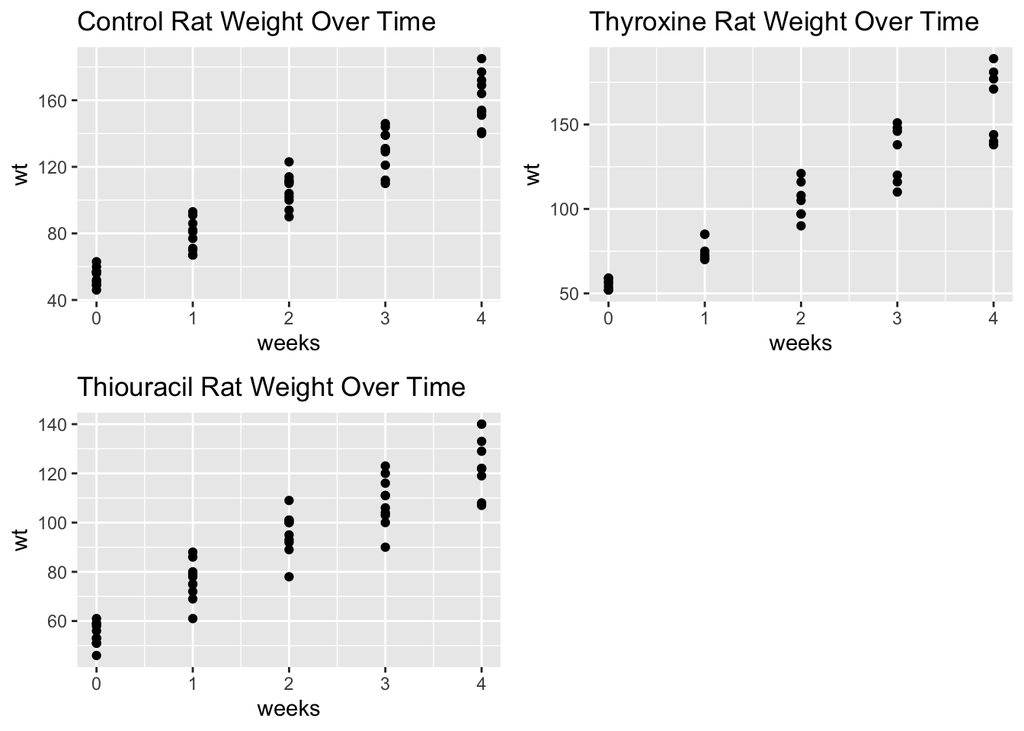

```r
controlp <- ratdrink %>%
  filter(treat == "control") %>%
  ggplot(aes(x = weeks, y = wt)) + geom_point() +
  labs(title = "Control Rat Weight Over Time")
thyp <- ratdrink %>%
  filter(treat == "thyroxine") %>%
  ggplot(aes(x = weeks, y = wt)) + geom_point() +
  labs(title = "Thyroxine Rat Weight Over Time")
thip <- ratdrink %>%
  filter(treat == "thiouracil") %>%
  ggplot(aes(x = weeks, y = wt)) + geom_point() +
  labs(title = "Thiouracil Rat Weight Over Time")
grid.arrange(controlp, thyp, thip, ncol = 2)
```

### 11.1b

Fit a linear longitudinal model that allows for a random slope and intercept for each rat. Each group should have a different mean line. Give interpretation for the following estimates:

- The fixed effect intercept term.
- The interaction between thiouracil and week
- The intercept random effect SD.

```r
library(tidyverse)
```

```r
library(lme4)
m1 <- lmer(wt ~ weeks * treat + (weeks | subject), data = ratdrink)
summary(m1)
```

```
## Linear mixed model fit by REML ['lmerMod']
## Formula: wt ~ weeks * treat + (weeks | subject)
##    Data: ratdrink
##
## REML criterion at convergence: 878.7
##
## Scaled residuals:
##      Min       1Q   Median       3Q      Max
## -1.83136 -0.54991  0.04003  0.58230  2.03660
##
## Random effects:
##  Groups   Name        Variance Std.Dev. Corr
##  subject  (Intercept) 32.49    5.700
##           weeks       14.14    3.760    -0.13
##  Residual             18.90    4.348
## Number of obs: 135, groups:  subject, 27
##
## Fixed effects:
##                       Estimate Std. Error t value
## (Intercept)            52.8800     2.0937  25.256
## weeks                  26.4800     1.2661  20.915
## treatthiouracil         4.7800     2.9610   1.614
## treatthyroxine         -0.7943     3.2628  -0.243
## weeks:treatthiouracil  -9.3700     1.7905  -5.233
## weeks:treatthyroxine    0.6629     1.9730   0.336
##
## Correlation of Fixed Effects:
##             (Intr) weeks  trtthr trtthy wks:trtthr
## weeks       -0.250
## treatthircl -0.707  0.177
## treatthyrxn -0.642  0.160  0.454
## wks:trtthrc  0.177 -0.707 -0.250 -0.113
## wks:trtthyr  0.160 -0.642 -0.113 -0.250  0.454
```

- The fixed effect intercept term : Similarly to GLM, the fixed effects intercept indicates that the average weight of control mice is 52.8 (no units in data sheet) on average.
- The interaction between `thiouracil` and `weeks` : The weight of mice goes down by 9 in thiouracil treated mice as compared to control mice dependent on weeks.
- The intercept random effect SD : The variability between subjects within a treatment group is 5.7, the random effect intercept SD.

### 11.1c

Check whether there is a significant treatment effect.

```r
library(pbkrtest)
m2 <- lmer(wt ~ weeks + (weeks | subject), data = ratdrink)
KRmodcomp(m1, m2)
```

```
## large : wt ~ weeks * treat + (weeks | subject)
## small : wt ~ weeks + (weeks | subject)
##          stat     ndf     ddf F.scaling   p.value
## Ftest  8.7125  4.0000 26.8141   0.94552 0.0001215 ***
## ---
## Signif. codes:  0 '***' 0.001 '**' 0.01 '*' 0.05 '.' 0.1 ' ' 1
```

The p-value of the F-test indicates that there is a significant effect of the treatment.

### 11.1d

Construct diagnostic plots showing the residuals against the fitted values and a QQ plot of the residuals. Interpret.

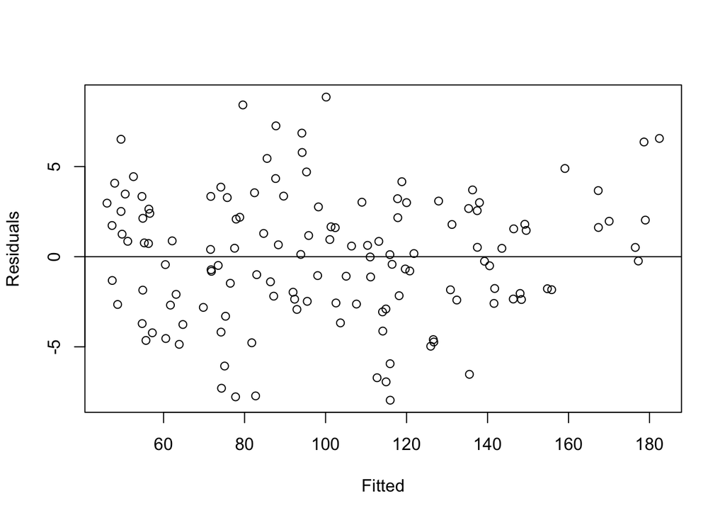

```r
plot(resid(m1) ~ fitted(m1), xlab = "Fitted", ylab = "Residuals")
abline(h = 0 )
```

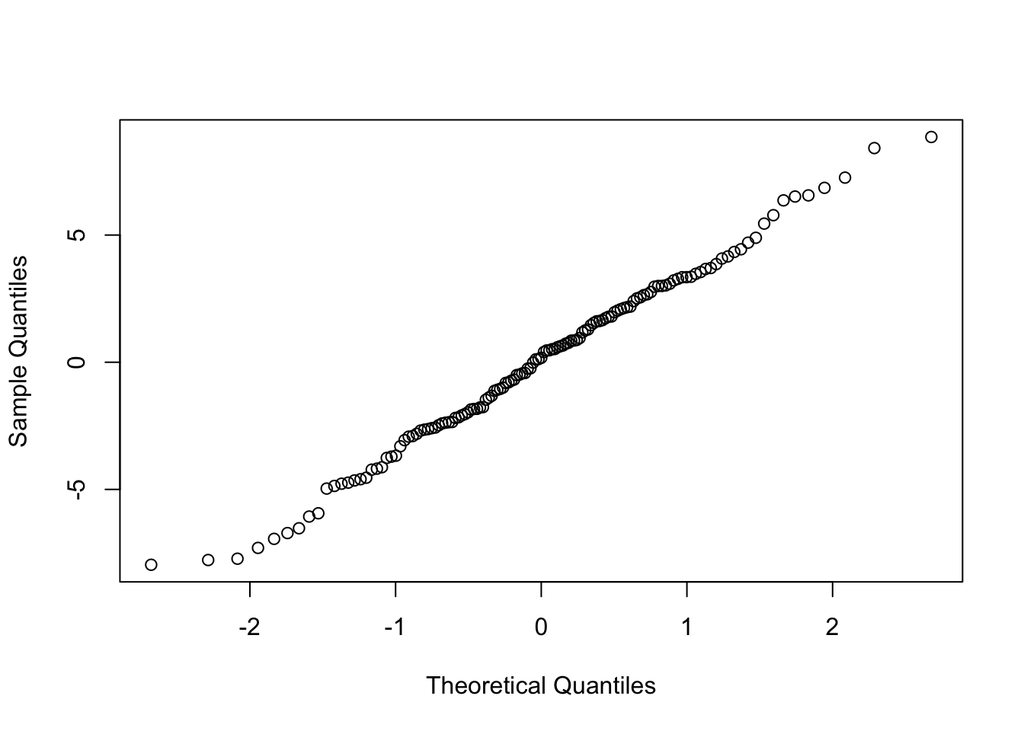

```r
qqnorm(resid(m1), main = "")
```

The QQ plot shows that there don’t seem to be deviations from the normality assumption.

### 11.1e

Construct confidence intervals for the parameters of the model. Which random effect terms may not be significant? Is the thyroxine group significantly different from the control group?

```r
confint(m1, method = "boot")
```

```
##                             2.5 %     97.5 %
## .sig01                  3.4926137  7.7290014
## .sig02                 -0.5812121  0.4315152
## .sig03                  2.7515107  5.1558643
## .sigma                  3.5600767  4.9961075
## (Intercept)            48.7296735 57.0464732
## weeks                  24.1924421 28.9122111
## treatthiouracil        -0.3843394 10.1230840
## treatthyroxine         -7.9521372  5.8181495
## weeks:treatthiouracil -12.9566564 -5.3967165
## weeks:treatthyroxine   -3.0775373  4.2726621
```

## Q4. ELMR Exercise 13.1 (p295)

The variables are: + `resp` an indicator of wheeze status (1 = yes, 0 = no) + `id` an identifier for the child + `age` 7yrs = -2, 8yrs = -1, 9yrs = 0, 10yrs = 1 + `smoke` an indicator of maternal smoking at the first year of the study (1 = smoker, 0 = nonsmoker)

```r
ohio %>% head(5)
```

```
##   resp id age smoke
## 1    0  0  -2     0
## 2    0  0  -1     0
## 3    0  0   0     0
## 4    0  0   1     0
## 5    0  1  -2     0
```

### 13.1a

Do any of the mothers in the study change their smoking status during the period of observation?

```r
ohio %>%
  dplyr::select(id, smoke) %>%
  n_distinct()
```

```
## [1] 537
```

There are 537 children, so there should be 537 unique combinations of `id` and `smoke` if the mothers did not change their smoking status. Since there are 537 unique combinations, that means no mothers changed her smoking status. If there were mothers who did change their smoking status, there would be more than 537 unique combinations.

### 13.1b

Construct a table that shows proportion of children who wheeze for 0, 1, 2, 3 or 4 years broken down by maternal smoking status.

```r
xtabs(~ smoke + resp, ohio)
```

```
##      resp
## smoke    0    1
##     0 1205  195
##     1  617  131
```

```r
library(gtsummary)
ohio %>%
  tbl_strata(strata = smoke,
             .tbl_fun = ~ .x %>%
  tbl_cross(row = resp, col = age, percent = "cell")) %>%
  bold_labels()
```

|  | **0** -2 | **0** -1 | **0** 0 | **0** 1 | **0** Total | **1** -2 | **1** -1 | **1** 0 | **1** 1 | **1** Total |
| --- | --- | --- | --- | --- | --- | --- | --- | --- | --- | --- |
| resp |  |  |  |  |  |  |  |  |  |  |
| 0 | 294 (21%) | 298 (21%) | 300 (21%) | 313 (22%) | 1,205 (86%) | 156 (21%) | 148 (20%) | 152 (20%) | 161 (22%) | 617 (82%) |
| 1 | 56 (4.0%) | 52 (3.7%) | 50 (3.6%) | 37 (2.6%) | 195 (14%) | 31 (4.1%) | 39 (5.2%) | 35 (4.7%) | 26 (3.5%) | 131 (18%) |
| Total | 350 (25%) | 350 (25%) | 350 (25%) | 350 (25%) | 1,400 (100%) | 187 (25%) | 187 (25%) | 187 (25%) | 187 (25%) | 748 (100%) |

### 13.1c

Make plot which shows how the proportion of children wheezing changes by age with a separate line for smoking and nonsmoking mothers.

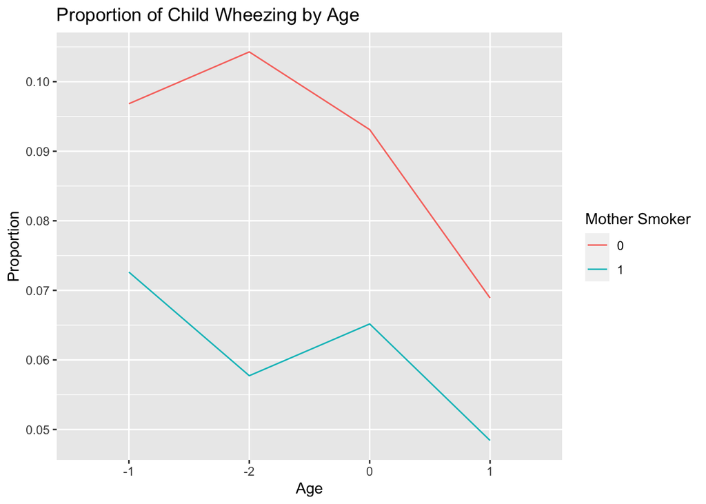

```r
props <- xtabs(~ age + resp + smoke, ohio) %>%
  as_tibble()
props$np <- props$n/537
props %>%
  filter(resp == 1) %>%
  ggplot() +
  geom_line(aes(x = age, y = np, group = smoke, col = as.factor(smoke))) +
  labs(x = "Age", y = "Proportion",
                      title = "Proportion of Child Wheezing by Age",
                      col = "Mother Smoker")
```

```r
  scale_color_manual(values = c("0" = "red", "1" = "green"),
                     labels = c("Mother not a smoker", "Mother smokes"))
```

[output not shown]

### 13.1d

4. Group the data by child to count the total (out of four) years of wheezing. Fit a binomial GLM to this response to check for a maternal smoking effect. Does this prove there is a smoking effect or could there be another plausible explanation?

```r
df1 <- aggregate(ohio$smoke, list(ohio$id), FUN=sum) %>%
  as_data_frame() %>%
  dplyr::rename("mom_smoke" = "x", "id" = "Group.1")

ohiobin <- aggregate(ohio$resp, list(ohio$id), FUN=sum) %>%
  mutate(not_wheeze = 4 - x) %>%
  dplyr::rename("years_wheezed" = "x", "id" = "Group.1") %>%
  full_join(df1, by = "id")
ohiobin$smoke <- ifelse(ohiobin$mom_smoke != 0, 1, 0)
ohiobin %>% head(5)
```

```
##   id years_wheezed not_wheeze mom_smoke smoke
## 1  0             0          4         0     0
## 2  1             0          4         0     0
## 3  2             0          4         0     0
## 4  3             0          4         0     0
## 5  4             0          4         0     0
```

```r
glm(cbind(years_wheezed, not_wheeze) ~ smoke, family = binomial, data = ohiobin) %>%
  summary()
```

```
##
## Call:
## glm(formula = cbind(years_wheezed, not_wheeze) ~ smoke, family = binomial,
##     data = ohiobin)
##
## Deviance Residuals:
##     Min       1Q   Median       3Q      Max
## -1.2411  -1.0954  -1.0954   0.5863   3.9711
##
## Coefficients:
##             Estimate Std. Error z value Pr(>|z|)
## (Intercept) -1.82124    0.07719 -23.595   <2e-16 ***
## smoke        0.27156    0.12334   2.202   0.0277 *
## ---
## Signif. codes:  0 '***' 0.001 '**' 0.01 '*' 0.05 '.' 0.1 ' ' 1
##
## (Dispersion parameter for binomial family taken to be 1)
##
##     Null deviance: 1045.3  on 536  degrees of freedom
## Residual deviance: 1040.5  on 535  degrees of freedom
## AIC: 1337.9
##
## Number of Fisher Scoring iterations: 4
```

In the binomial model, maternal smoking is significant. This doesn’t prove that there’s a smoking effect since there could be something confounding the results.

### 13.1e

5. Fit a model for each individual response using a GLMM fit using penalized quasi-likelihood. Describe the effects of age and maternal smoking. How do the odds of wheezing change numerically over time?

```r
library(MASS)
pqlmod <- glmmPQL(resp ~ age + smoke, random = ~ 1 | id, family = binomial, data = ohio)
summary(pqlmod)
```

```
## Linear mixed-effects model fit by maximum likelihood
##   Data: ohio
##   AIC BIC logLik
##    NA  NA     NA
##
## Random effects:
##  Formula: ~1 | id
##         (Intercept)  Residual
## StdDev:    2.057175 0.6355563
##
## Variance function:
##  Structure: fixed weights
##  Formula: ~invwt
## Fixed effects:  resp ~ age + smoke
##                  Value  Std.Error   DF    t-value p-value
## (Intercept) -2.7658365 0.14218299 1610 -19.452654  0.0000
## age         -0.1815756 0.04365164 1610  -4.159652  0.0000
## smoke        0.3251839 0.23131699  535   1.405793  0.1604
##  Correlation:
##       (Intr) age
## age    0.197
## smoke -0.591 -0.003
##
## Standardized Within-Group Residuals:
##        Min         Q1        Med         Q3        Max
## -2.6145143 -0.2829352 -0.2583719 -0.2154580  3.4443795
##
## Number of Observations: 2148
## Number of Groups: 537
```

The odds of wheezing decreases by 17% with every year increase in age. (exp(-.1816) = .8339) when the mother of the child was not a smoker. Children with a maternal smoker are found to wheeze 38% more than children who’s mom didn’t smoke on average, holding age constant. But with `age` in the model, `smoke` is no longer significant.

### 13.1f

6. Now fit the same model but using adaptive Gaussian-Hermit quadrature. Compare to the previous model fit.

```r
ghmod <- glmer(resp ~ age + smoke + (1 | id), nAGQ = 25, family = binomial, data = ohio)
summary(ghmod)
```

```
## Generalized linear mixed model fit by maximum likelihood (Adaptive
##   Gauss-Hermite Quadrature, nAGQ = 25) [glmerMod]
##  Family: binomial  ( logit )
## Formula: resp ~ age + smoke + (1 | id)
##    Data: ohio
##
##      AIC      BIC   logLik deviance df.resid
##   1603.3   1626.0   -797.6   1595.3     2144
##
## Scaled residuals:
##     Min      1Q  Median      3Q     Max
## -1.3730 -0.2011 -0.1773 -0.1487  2.5076
##
## Random effects:
##  Groups Name        Variance Std.Dev.
##  id     (Intercept) 4.687    2.165
## Number of obs: 2148, groups:  id, 537
##
## Fixed effects:
##             Estimate Std. Error z value Pr(>|z|)
## (Intercept) -3.10153    0.21905 -14.159  < 2e-16 ***
## age         -0.17563    0.06768  -2.595  0.00946 **
## smoke        0.39857    0.27309   1.459  0.14444
## ---
## Signif. codes:  0 '***' 0.001 '**' 0.01 '*' 0.05 '.' 0.1 ' ' 1
##
## Correlation of Fixed Effects:
##       (Intr) age
## age    0.244
## smoke -0.493 -0.008
```

### 13.1g OPTIONAL

7. Use INLA to fit the same model. What does this model say about the effect of age and maternal smoking?

### 13.1h OPTIONAL

8. Use STAN to fit the same model. Check the MCMC diagnostics and again dis- cuss the age and maternal smoking effects.

### 13.1i

1. Fit the model using GEE. Use an autoregressive rather than exchangeable error structure. Compare the results to the previous model fits. In your model, what indicates that a child who already wheezes is likely to continue to wheeze?

```r
library(geepack)
geemod <- geeglm(resp ~ age + smoke, id = id, corstr = "ar1", scale.fix = TRUE, data = ohio, family =binomial(link = "logit"))
summary(geemod)
```

```
##
## Call:
## geeglm(formula = resp ~ age + smoke, family = binomial(link = "logit"),
##     data = ohio, id = id, corstr = "ar1", scale.fix = TRUE)
##
##  Coefficients:
##             Estimate  Std.err    Wald Pr(>|W|)
## (Intercept) -1.90262  0.11533 272.174   <2e-16 ***
## age         -0.11490  0.04544   6.394   0.0115 *
## smoke        0.23340  0.18137   1.656   0.1981
## ---
## Signif. codes:  0 '***' 0.001 '**' 0.01 '*' 0.05 '.' 0.1 ' ' 1
##
## Correlation structure = ar1
## Scale is fixed.
##
##   Link = identity
##
## Estimated Correlation Parameters:
##       Estimate Std.err
## alpha   0.5007 0.03799
## Number of clusters:   537  Maximum cluster size: 4
```

The autoregressive correlation structure indicates that a child who already wheezes is likely to continue to wheeze.

### 13.1j

10. What is your overall conclusion regarding the effect of age and maternal smoking? Can we trust the GLM result or are the GLMM models preferable?